# GISTEMP : Temperature Annual Means 1880 - 2014 : Variation by Northern/Southern Tropical, Temperate, Polar Zones over Time

2015.08.02

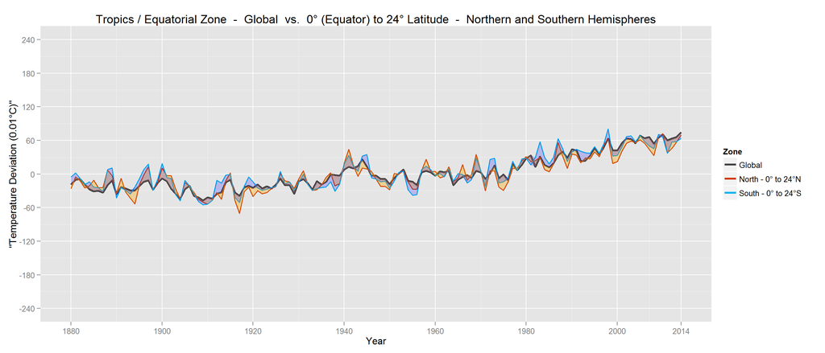

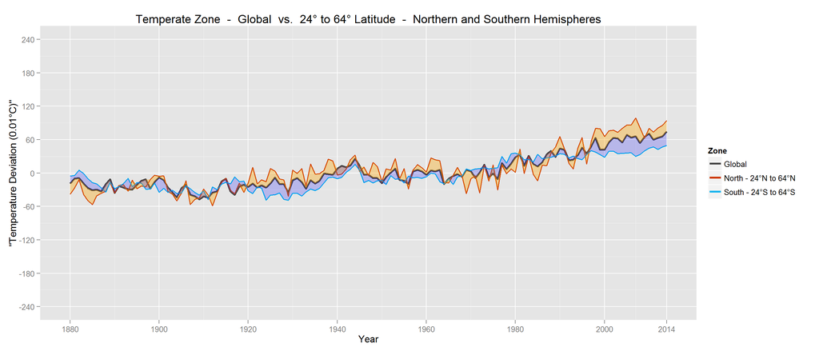

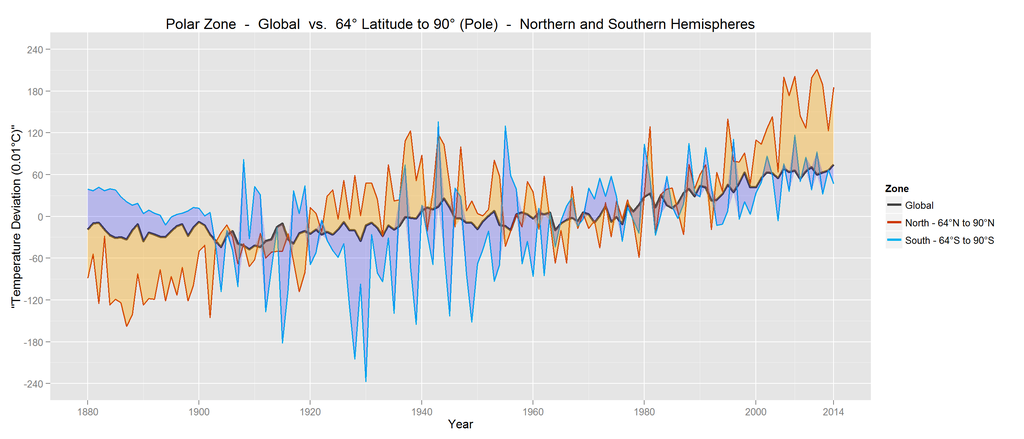

I used the provided GISTEMP data ( http://data.giss.nasa.gov/gistemp/ ) and R Markdown for the graphs.

These three graphs show the annual temperature variation, split into 3 zones:

- Tropical / Equatorial : 0° (Equator) to 24° Latitude
- Temperate : 24° to 64° Latitude
- Polar: 64° to 90° (Pole) Latitude

The X-axis shows the year, from 1880 - 2014. The Y-axis shows the deviations (in 0.01°C) of the zone’s annual temperature from the 1951-1980 means.

For each graph, I compared the global measurement against the Northern and Southern hemispheres’ zones. The difference between the Northern zone and the global is coloured in orange, and the difference between the Southern zone and the global is coloured in blue.

Observations:

- Gradual upward trend in global and zonal temperatures from 1880 to 2014
- Since each graph uses the same Y-axis scale, variation is small for the tropical zones, larger for the temperate zones, and largest for the polar zoness - the further from the Equator, the larger the variation regardless of hemisphere.
- There is a great increase in the Norther Polar Zone deviation from around 2000 - 2014, as can be seen from the large orange area of the third graph.